# Strategic Solutions for Facility Cost Optimization

- Show All Code
- Hide All Code

The Africa West Area Meetinghouse Strategy - Achieving Self-Reliance

Author

Felix Jena

### Reasearch Question

What strategies can the Africa West Area implement to achieve long-term self-reliance by reducing facility costs, and how would you approach diagnosing the situation and developing a strategic plan?

### Libraries Used & Data Preparation

```r
pacman::p_load(tidyr, ggplot2, dplyr, gridExtra)

# Church Attendance Growth
attendance_growth <- data.frame(
  Year = c(2017, 2018, 2019, 2020, 2021, 2022),
  Growth = c(7.5, 8.0, 7.9, 8.1, 8.2, 8.1)
)

# Number of Meetinghouses
meetinghouses <- data.frame(
  Year = c(2017, 2018, 2019, 2020, 2021, 2022),
  Church_built = c(175, 200, 225, 250, 275, 300),
  Leases = c(200, 250, 300, 350, 425, 500),
  Other = c(20, 20, 25, 20, 25, 25)
)

# Meetinghouse Operations Cost per Square Foot
operations_cost <- data.frame(
  Year = c(2017, 2018, 2019, 2020, 2021, 2022),
  Total_cost_per_sqft = c(2.00, 2.25, 2.50, 3.00, 3.50, 4.00),
  Lease_cost_percent = c(15, 16, 17, 21, 21, 25),
  Maintenance_percent = c(50, 52, 47, 50, 49, 45),
  Other_cost_percent = c(35, 32, 36, 29, 30, 30)
)

construction_data <- data.frame(
  Type = c("Church Meetinghouse", "Benchmark Buildings"),
  Cost_per_sqft = c(125, 65)
)

land_cost <- 500000
total_meetinghouse_cost <- 1500000 + land_cost

growth_data <- data.frame(
  Year = 2022:2032,
  Urbanization_Rate = seq(3.5, 4.5, length.out = 11),
  Economic_Growth = rep(3.5, 11)
)
```

### Assumptions and Diagnostic Approach

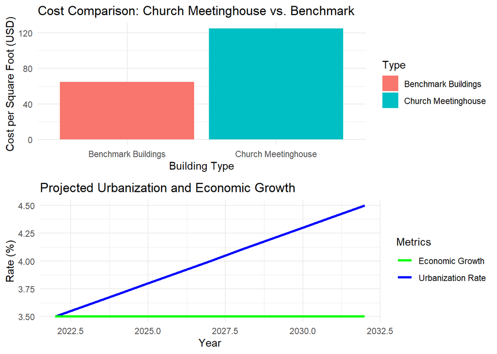

```r
p1 <- ggplot(construction_data, aes(x = Type, y = Cost_per_sqft, fill = Type)) +
  geom_bar(stat = "identity") +
  ggtitle("Cost Comparison: Church Meetinghouse vs. Benchmark") +
  xlab("Building Type") +
  ylab("Cost per Square Foot (USD)") +
  theme_minimal()

p2 <- ggplot(growth_data, aes(x = Year)) +
  geom_line(aes(y = Urbanization_Rate, color = "Urbanization Rate"), size = 1.2) +
  geom_line(aes(y = Economic_Growth, color = "Economic Growth"), size = 1.2) +
  ggtitle("Projected Urbanization and Economic Growth") +
  xlab("Year") +
  ylab("Rate (%)") +
  scale_color_manual(name = "Metrics", values = c("Urbanization Rate" = "blue", "Economic Growth" = "green")) +
  theme_minimal()

grid.arrange(p1, p2, nrow = 2)
```

Benchmark construction cost: $65/sqft (schools, government buildings, hospitals)  
The urbanization rate increase implies a growing demand for facilities like meetinghouses in urban centers, where land acquisition and construction costs are typically higher.  
Economic growth remains steady at 3.5% per year, indicating limited capacity for significant increases in local contributions (e.g., tithes or offerings).

To address the challenges highlighted by these trends, a structured diagnostic effort is necessary:

1. **Data Collection:**
   - Analyze utilization rates of current meetinghouses to identify underutilized or overcrowded facilities.
   - Gather member feedback on facility needs and preferences for meetinghouses.
   - Conduct cost analyses of leasing vs. owning properties in key urban and rural areas.
2. **Benchmarking:**
   - Compare construction costs per square foot with regional benchmarks ($65/sqft for schools, hospitals, etc.).
   - Evaluate successful strategies from other Church areas with similar growth challenges.
3. **Stakeholder Engagement:**
   - Collaborate with local leaders (DTA, AMFM) to understand unique regional challenges.
   - Involve members to foster ownership and participation in meetinghouse solutions.

### Church Attendance Growth & Number of Meetinghouses

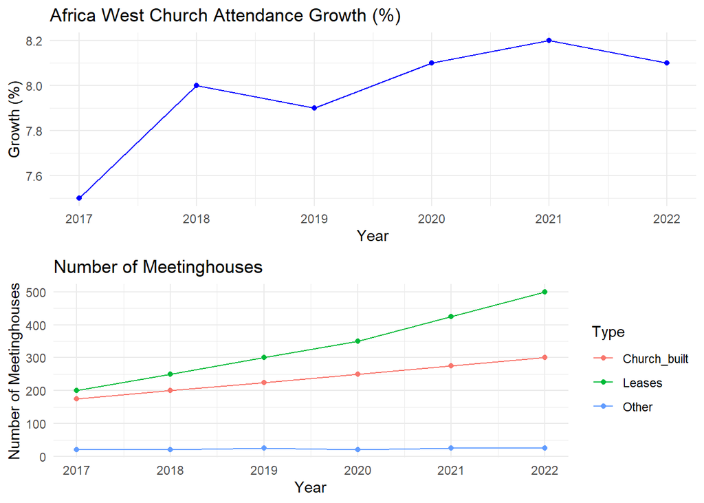

```r
p1 <- ggplot(attendance_growth, aes(x = Year, y = Growth)) +
  geom_line(color = "blue") +
  geom_point(color = "blue") +
  ggtitle("Africa West Church Attendance Growth (%)") +
  xlab("Year") +
  ylab("Growth (%)") +
  theme_minimal()

meetinghouses_long <- gather(meetinghouses, Type, Count, -Year)
p2 <- ggplot(meetinghouses_long, aes(x = Year, y = Count, color = Type)) +
  geom_line() +
  geom_point() +
  ggtitle("Number of Meetinghouses") +
  xlab("Year") +
  ylab("Number of Meetinghouses") +
  theme_minimal()

grid.arrange(p1, p2, nrow = 2)
```

### Meetinghouse Operations Cost per Square Foot

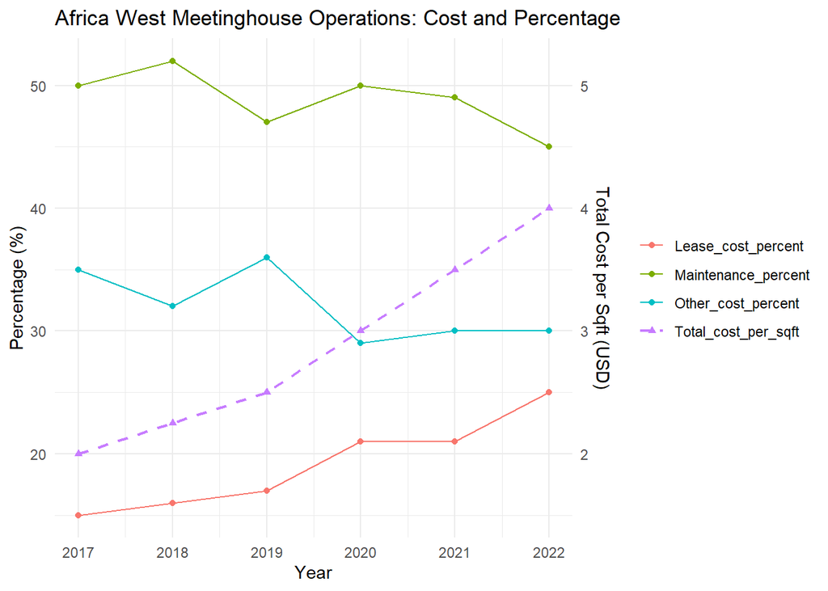

```r
# Reshaping to plot percentages
operations_cost_long <- gather(operations_cost, Category, Value, -Year)

# Dual-axis handling
cost_per_sqft <- operations_cost %>%
  select(Year, Total_cost_per_sqft)

ggplot() +
  # Percentage categories
  geom_line(data = operations_cost_long %>% filter(Category != "Total_cost_per_sqft"),
            aes(x = Year, y = Value, color = Category)) +
  geom_point(data = operations_cost_long %>% filter(Category != "Total_cost_per_sqft"),
             aes(x = Year, y = Value, color = Category)) +
  # Secondary y-axis
  geom_line(data = cost_per_sqft, aes(x = Year, y = Total_cost_per_sqft * 10, color = "Total_cost_per_sqft"),
            size = 0.8, linetype = "dashed") +
  geom_point(data = cost_per_sqft, aes(x = Year, y = Total_cost_per_sqft * 10, color = "Total_cost_per_sqft"),
             size = 1.5, shape = 17) +
  scale_y_continuous(name = "Percentage (%)",
                     sec.axis = sec_axis(~./10, name = "Total Cost per Sqft (USD)")) +
  ggtitle("Africa West Meetinghouse Operations: Cost and Percentage") +
  xlab("Year") +
  ylab("Cost / Percentage") +
  theme_minimal() +
  theme(legend.title = element_blank())
```

The total cost per square foot has doubled from $2.00 in 2017 to $4.00 in 2022, driven largely by an increase in lease costs (rising from 15% to 25% of total costs).  
Maintenance costs have decreased slightly (from 50% to 45%), while utility costs remain relatively stable at ~30%.

### Strategic Recommendations

1. **Optimize Current Facility Usage:**
   - Implementing multi-purpose scheduling to maximize meetinghouse usage and reduce the need for additional facilities.
   - Consolidating underutilized meetinghouses where practical to reduce maintenance and operational costs.
2. **Transition from Leasing to Ownership:**
   - Prioritizing purchasing land and constructing owned meetinghouses in urban areas with high lease costs.
   - Conducting cost-benefit analyses to identify the most cost-effective lease-to-own transitions.
3. **Adopt Cost-Effective Construction Practices:**
   - Using “pre-made” and “easy-to-assemble” designs to bring construction costs closer to the $65/sqft benchmark.
   - Designing smaller, scalable meetinghouses that can be expanded as membership grows.
4. **Enhance Member Contributions:**
   - Promoting tithing and fundraising education to increase local contributions and reduce reliance on external funding.
   - Encourage community partnerships to share resources and reduce facility costs.
5. **Develop a Phased Implementation Plan:**
   - Phase 1: Piloting cost-effective construction projects and optimizing scheduling at existing facilities.
   - Phase 2: Evaluating the pilot results and scaling successful initiatives to other locations.
   - Phase 3: Monitoring progress and adapting strategies based on membership growth and financial performance.